# AIRBNB MILANO TESINA

### REGRESSIONE VS REGRESSION TREE

```r
# Converto le variabili testuali in Factor per l'albero
df_final$room_type <- as.factor(df_final$room_type)
df_final$host_is_superhost <- as.factor(df_final$host_is_superhost)

# CREAZIONE DELL'ALBERO BASE
# Uso le stesse variabili del modello di regressione
albero_base <- tree(log_price ~ accommodates + bedrooms + bathrooms +
                      host_is_superhost + review_scores_rating +
                      log_reviews + minimum_nights + availability_365 +
                      distanza_centro_km + room_type,
                    data = df_final)

summary(albero_base)
```

```
##
## Regression tree:
## tree(formula = log_price ~ accommodates + bedrooms + bathrooms +
##     host_is_superhost + review_scores_rating + log_reviews +
##     minimum_nights + availability_365 + distanza_centro_km +
##     room_type, data = df_final)
## Variables actually used in tree construction:
## [1] "distanza_centro_km" "bedrooms"           "log_reviews"
## [4] "bathrooms"          "room_type"
## Number of terminal nodes:  10
## Residual mean deviance:  0.1764 = 3000 / 17000
## Distribution of residuals:
##     Min.  1st Qu.   Median     Mean  3rd Qu.     Max.
## -1.78700 -0.27940 -0.03326  0.00000  0.24930  2.19700
```

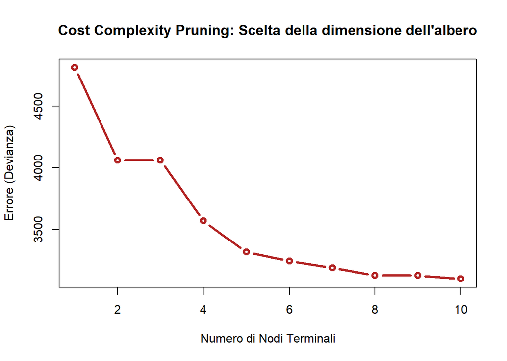

```r
# CROSS-VALIDATION E PRUNING
set.seed(123)
cv_albero <- cv.tree(albero_base)

# Grafico del CCP
plot(cv_albero$size, cv_albero$dev, type = "b", lwd = 3, col = "firebrick",
     xlab = "Numero di Nodi Terminali", ylab = "Errore (Devianza)",
     main = "Cost Complexity Pruning: Scelta della dimensione dell'albero")
```

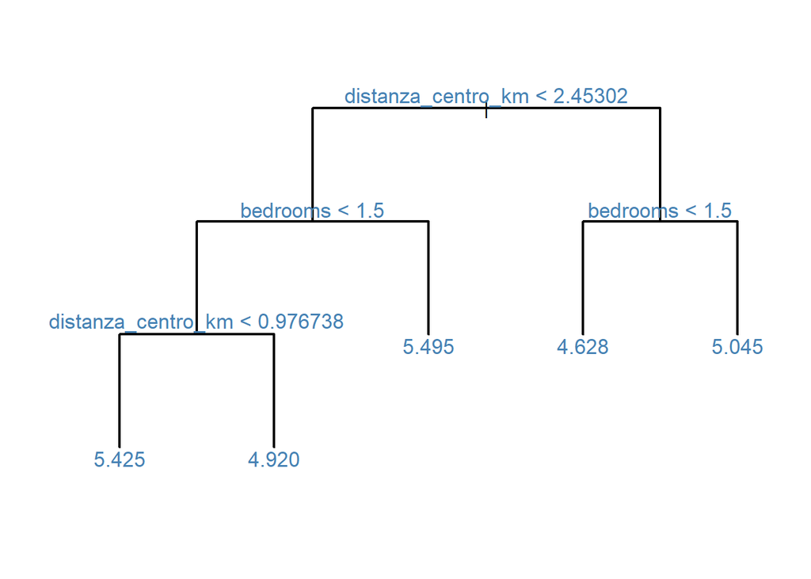

```r
# POTATURA E GRAFICO FINALE
# Scegliamo di potare l'albero a un numero leggibile di nodi (es. 5 o 6 nodi),
albero_potato <- prune.tree(albero_base, best = 5)

# Grafico definitivo
plot(albero_potato, type = "uniform", lwd = 2)
text(albero_potato, cex = 1.1, pretty = 0, col = "steelblue")
```

Al fine di esplorare le non linearità del mercato e ottenere una segmentazione dello spazio dei predittori, si è proceduto alla stima di un singolo albero di regressione utilizzato per prevere il log_price.

Tuttavia, un albero fatto crescere senza vincoli tende fisiologicamente all’*overfitting*, memorizzando il rumore statistico del *training set* a discapito della capacità di generalizzazione. Per ovviare a questo problema, è stata applicata la tecnica del **Cost Complexity Pruning**, supportata da una procedura di *Cross-Validation*, come illustrato nel grafico della devianza in funzione della dimensione dell’albero.

L’analisi visiva della curva di costo complessità mostra un decremento drastico dell’errore (devianza) fino al raggiungimento di 5 nodi terminali, punto oltre il quale la curva si stabilizza e in cui ho deciso di tagliare l’albero.

### Interpretazione Economica

L’albero di regressione potato permette di isolare le interazioni non-lineari che il modello OLS classico poteva solo approssimare. L’algoritmo ha selezionato due predittori dominanti per la segmentazione del mercato: la **distanza dal centro** e il **numero di camere da letto** (`bedrooms`).

In conclusione, l’albero di decisione ha dimostrato che l’aumento di prezzo per la centralità urbana non è lineare, ma segue dinamiche a gradoni fortemente condizionate dalla dimensione strutturale dell’immobile, confermando l’efficacia dei metodi basati su alberi nel far emergere l’eterogeneità nascosta nei dati.

### RANDOM FOREST

```r
# ADDESTRAMENTO DELLA RF
set.seed(123)

modello_rf <- randomForest(log_price ~ accommodates + bedrooms + bathrooms +
                             host_is_superhost + review_scores_rating +
                             log_reviews + minimum_nights + availability_365 +
                             distanza_centro_km + room_type,
                           data = df_final,
                           ntree = 500,       # Costruiamo 500 alberi
                           importance = TRUE) # calcola l'importanza delle variabili

# VISUALIZZAZIONE DEI RISULTATI
# Guardiamo la % di varianza spiegata
cat("--- RISULTATI RANDOM FOREST ---\n")
```

```
## --- RISULTATI RANDOM FOREST ---
```

```r
print(modello_rf)
```

```
##
## Call:
##  randomForest(formula = log_price ~ accommodates + bedrooms +      bathrooms + host_is_superhost + review_scores_rating + log_reviews +      minimum_nights + availability_365 + distanza_centro_km +      room_type, data = df_final, ntree = 500, importance = TRUE)
##                Type of random forest: regression
##                      Number of trees: 500
## No. of variables tried at each split: 3
##
##           Mean of squared residuals: 0.1364732
##                     % Var explained: 51.73
```

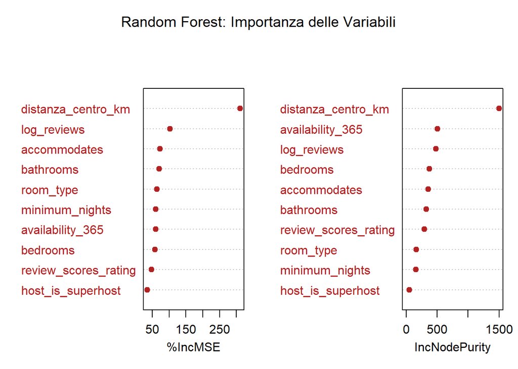

```r
# GRAFICO IMPORTANZA VAR
# Mostra quali variabili sono state più utili agli alberi per prevedere il prezzo
varImpPlot(modello_rf,
           main = "Random Forest: Importanza delle Variabili",
           col = "firebrick",
           pch = 19)
```

Per superare il limite intrinseco della *black-box* generato dall’aggregazione di 500 alberi, ho estratto le le misure di influenza relativa, così da quantificare il contributo di ogni predittore valutato secondo due metriche:

1. **%IncMSE (Aumento dell’Errore Quadratico Medio):** Misura di quanto peggiorerebbe la capacità predittiva del modello se i valori di una specifica variabile venissero permutati casualmente.
2. **IncNodePurity (Aumento della Purezza dei Nodi):** Misura la diminuzione totale della devianza residua (RSS) ottenuta grazie ai tagli operati su una determinata variabile su tutti i 500 alberi.

Dall’analisi dei grafici si evince che la **distanza dal centro** (`distanza_centro_km`) domina in modo l’algoritmo, confermandosi come il *driver* principale di *pricing* sul mercato di Milano, distaccando nettamente tutti gli altri fattori.

Infine, il grafico conferma l’irrilevanza di `host_is_superhost`, si posiziona all’ultimo posto assoluto in entrambe le metriche.

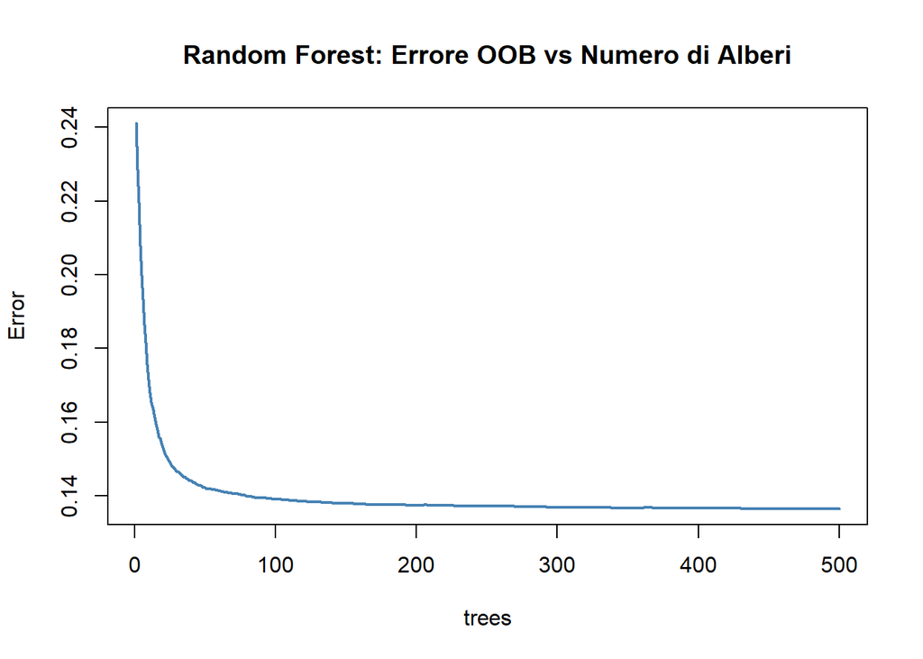

```r
#GRAFICO DI CONVERGENZA DELL'ERRORE
plot(modello_rf, main = "Random Forest: Errore OOB vs Numero di Alberi",
     lwd = 2, col = "steelblue")
```

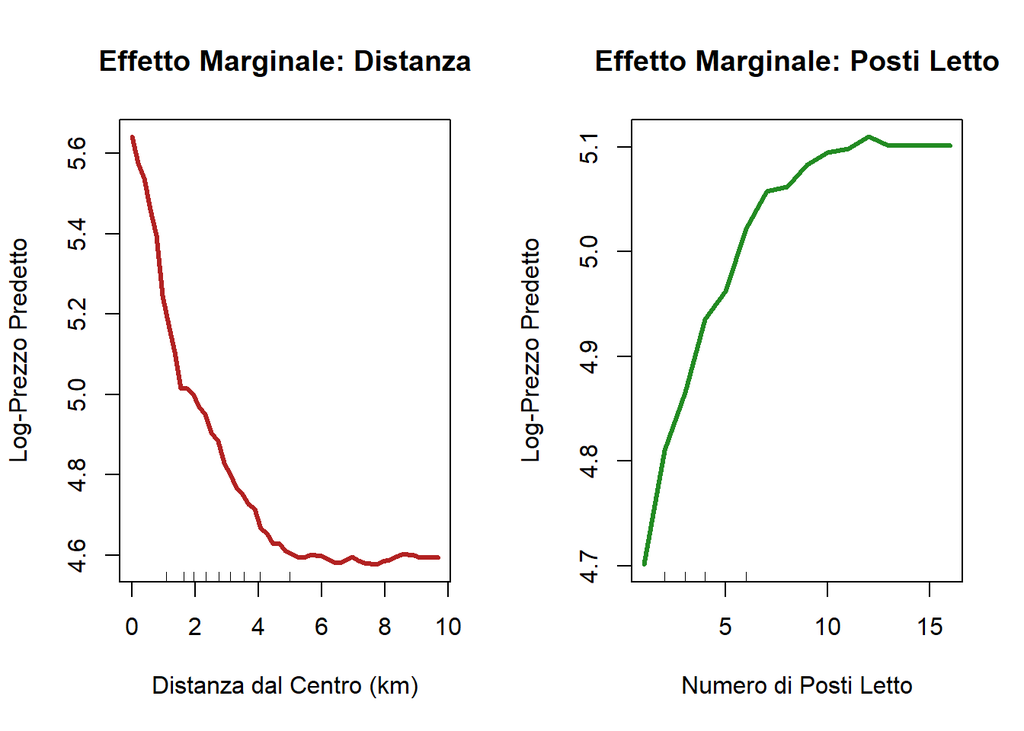

```r
# PARTIAL DEPENDENCE PLOTS (Effetti Marginali Non-Lineari)
par(mfrow = c(1, 2))

# PDP per la Distanza dal Centro
partialPlot(modello_rf, pred.data = as.data.frame(df_final),
            x.var = "distanza_centro_km",
            main = "Effetto Marginale: Distanza",
            xlab = "Distanza dal Centro (km)", ylab = "Log-Prezzo Predetto",
            lwd = 3, col = "firebrick")

# PDP per la Capacità Strutturale (Letti)
partialPlot(modello_rf, pred.data = as.data.frame(df_final),
            x.var = "accommodates",
            main = "Effetto Marginale: Posti Letto",
            xlab = "Numero di Posti Letto", ylab = "Log-Prezzo Predetto",
            lwd = 3, col = "forestgreen")
```

```r
par(mfrow = c(1, 1))
```

### Convergenza dell’Algoritmo ed Effetti Marginali Non-Lineari

Il grafico dell’**Errore OOB (Out-of-Bag) rispetto al numero di alberi** mostra che l’errore crolla durante l’addestramento dei primi 50-100 alberi, per poi stabilizzarsi asintoticamente. Questo mostra che la foresta ha raggiunto la convergenza.

Per rispondere al limite interpretativo del *Machine Learning*, ho utilizzato i **Partial Dependence Plots**. Questi grafici isolano l’effetto marginale di una singola variabile sul prezzo logaritmico predetto, mediando l’effetto di tutte le altre variabili presenti nel modello. I risultati offrono la spiegazione visiva del superamento prestazionale della Random Forest rispetto alla tradizionale regressione OLS:

- **Effetto Marginale della Distanza dal Centro (Curva Rossa):** Il modello log-lineare assumeva un deprezzamento spaziale costante (una retta inclinata negativamente in cui ogni chilometro pesa allo stesso modo). Il PDP smentisce questa assunzione: la curva mostra un crollo verticale del valore immobiliare esclusivamente nei primi 3-4 chilometri . Oltre la soglia dei 4-5 km, si stabilizza la pendenza. Questo dimostra che, superata la fascia semi-centrale, la svalutazione si arresta: trovarsi a 6 o a 8 km dal Duomo genera un impatto marginale praticamente nullo sul prezzo.
- **Effetto Marginale della Capacità Strutturale (Curva Verde):** L’analisi dei posti letto (`accommodates`)mostra che il log-prezzo predetto sale in modo ripido e quasi lineare passando da 1 a 4 o 5 posti letto, riflettendo la forte richiesta per monolocali e bilocali. Tuttavia, superata la soglia degli 8 posti letto, la curva inizia ad appiattirsi in modo significativo. L’algoritmo ha compreso che aggiungere posti letto estremi in una singola struttura (es. da 10 a 15 posti) non genera un incremento proporzionale e lineare di valore.

### Conclusione Generale

```r
# ESTRAZIONE PERFORMANCE RANDOM FOREST
# La Random Forest calcola lo Pseudo R-quadro sull'errore OOB
# Estraiamo l'R-quadro raggiunto con 500 alberi:
r2_rf <- modello_rf$rsq[500]

cat("\n--- IL CONFRONTO FINALE (Varianza Spiegata) ---\n")
```

```
##
## --- IL CONFRONTO FINALE (Varianza Spiegata) ---
```

```r
cat("1. Modello Econometrico (Interazioni): ~ 0.4333 (43.33%)\n")
```

```
## 1. Modello Econometrico (Interazioni): ~ 0.4333 (43.33%)
```

```r
cat("2. Modello PCR (Machine Learning Lineare): ~ 0.4301 (43.01%)\n")
```

```
## 2. Modello PCR (Machine Learning Lineare): ~ 0.4301 (43.01%)
```

```r
cat(sprintf("3. Random Forest (Machine Learning Non-Lineare): %.4f (%.2f%%)\n", r2_rf, r2_rf * 100))
```

```
## 3. Random Forest (Machine Learning Non-Lineare): 0.5173 (51.73%)
```

La Random Forest, esplorando autonomamente interazioni complesse e partizionamenti a gradoni che sarebbero molto difficili da modellare econometricamente, è riuscita a spiegare quasi il **9% di varianza in più** rispetto al miglior modello lineare. Questo risultato dimostra che il mercato di Airbnb a Milano è governato da dinamiche di *pricing* **non-lineari**. Il premio per la posizione centrale, ad esempio, non diminuisce linearmente chilometro dopo chilometro, ma crolla a scaglioni, e il valore delle recensioni interagisce con la metratura in modi che sfuggono all’OLS.

In conclusione, se lo scopo analitico è la stima esatta dell’impatto di una *policy* (es. “quanto vale una stanza in più?”), il Modello Econometrico rimane lo strumento migliore. Ma se l’obiettivo è la costruzione di un algoritmo di *pricing* capace di prevedere il reale valore di mercato di un immobile sulla piattaforma, le tecniche di *Machine Learning* basate su alberi, come la Random Forest, si sono dimostrate nettamente superiori, decretando la definitiva non-linearità del mercato immobiliare turistico milanese.